# DATA 6320 - Scenario 3

**Program Sections**

- Look for outliers
- Remove outliers
- Recode categorical data - label encoder
- Recode Categorical using a Defined Function
- Recode Categorical using dummy variables
- Recode Categorical using by merging two datasets

### Contents

- **Business Understanding**
  - Available resources, problems, goals
- **Data Understanding**
  - What data do you have available to you?
  - Install or Load tools or applications
    - Programming – Jupyter notebooks for Python or R Studio for R
    - BI/spreadsheets – Excel – PowerPivot - Tableau
  - Import or download the data
  - Format the data
  - View, explore, and summarize the data
- **Data Preparation**
  - Remove Columns
  - Remove Rows
  - Fill in null values
  - Replace or remove mistakes
  - **Remove outliers**
  - **Recode categorical or numerical features**
  - Construct new data feature engineering
  - For Supervised Learning, create X and Y
- **Modeling**
  - Split the data (Train/Test Split)
  - Transform the data
  - Setup models for machine learning/AI processes
  - Can also include developing the outline for visuals, dashboards or reports
- **Evaluation**
  - Hyper-parameter tuning
- **Deployment of models**

# --------------------------------------

# -------------------------------------

## Business Objective

- What is the relationship between annual income and loan amount. Is it a good predictor?
- Can we predict the amount for a loan?
- What features are most important in predicting loan amount?

## Technical Objective

- Review different data cleansing techniques to continue to improve
- Conduct a simple regression using scikit-learn
- Conduct a multiple regression using statsmodels
- Learn and perform Lasso and Ridge regression and tune its parameters

# -------------------------------

# --------------------------------

## Import Libraries

```python
#Code Block 01
import numpy as np
import pandas as pd
import matplotlib.pyplot as plt
import seaborn as sns
%matplotlib inline

pd.set_option('display.max_columns',500)

plt.style.use('seaborn-v0_8-colorblind') #a style that can be used for plots

sns.set_style('whitegrid')
```

```python
#obtain the list of available styles

plt.style.available
```

```
['Solarize_Light2',
 '_classic_test_patch',
 '_mpl-gallery',
 '_mpl-gallery-nogrid',
 'bmh',
 'classic',
 'dark_background',
 'fast',
 'fivethirtyeight',
 'ggplot',
 'grayscale',
 'seaborn-v0_8',
 'seaborn-v0_8-bright',
 'seaborn-v0_8-colorblind',
 'seaborn-v0_8-dark',
 'seaborn-v0_8-dark-palette',
 'seaborn-v0_8-darkgrid',
 'seaborn-v0_8-deep',
 'seaborn-v0_8-muted',
 'seaborn-v0_8-notebook',
 'seaborn-v0_8-paper',
 'seaborn-v0_8-pastel',
 'seaborn-v0_8-poster',
 'seaborn-v0_8-talk',
 'seaborn-v0_8-ticks',
 'seaborn-v0_8-white',
 'seaborn-v0_8-whitegrid',
 'tableau-colorblind10']
```

### Import the data and create dataframes that can then be cleansed, recoded, transformed, and split.

## Import Data

Top

## Look for outliers

```python
#Code Block 02

df_loandata_clean = pd.read_csv('data/DATA6320_Scenario3.csv', index_col = 0, header = 0)
df_loandata_clean.info()
```

```
<class 'pandas.core.frame.DataFrame'>
Index: 37132 entries, 0 to 37131
Data columns (total 27 columns):
 #   Column                       Non-Null Count  Dtype
---  ------                       --------------  -----
 0   member_id                    37132 non-null  int64
 1   loan_amnt                    37132 non-null  int64
 2   term                         37132 non-null  int64
 3   int_rate                     37132 non-null  float64
 4   annual_inc                   37132 non-null  float64
 5   delinq_2yrs                  37132 non-null  int64
 6   inq_last_6mths               37132 non-null  int64
 7   mths_since_last_delinq       37132 non-null  int64
 8   mths_since_last_record       37132 non-null  int64
 9   open_acc                     37132 non-null  int64
```

[output cut: 19 more lines]

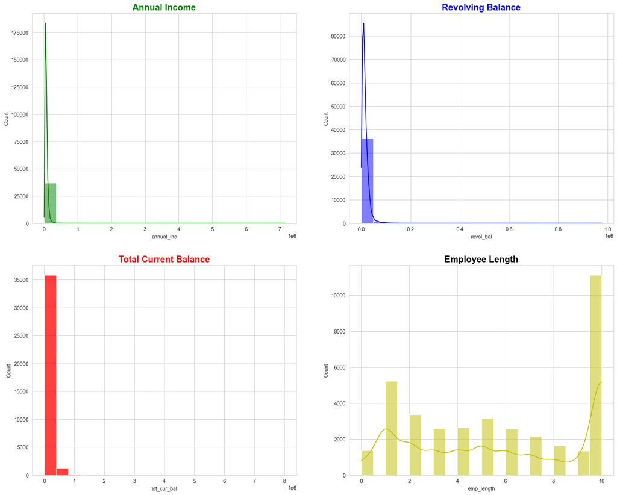

```python
#Code Block 03

plt.figure(figsize=(20,16))

plt.subplot(221)
plt.title('Annual Income', fontweight='bold', color = 'green', fontsize='17', horizontalalignment='center')
sns.histplot(df_loandata_clean['annual_inc'], color="g", bins = 20, kde=True)

plt.subplot(222)
plt.title('Revolving Balance', fontweight='bold', color = 'blue', fontsize='17', horizontalalignment='center')
sns.histplot(df_loandata_clean['revol_bal'], color="b", bins = 20, kde=True)

plt.subplot(223)
plt.title('Total Current Balance', fontweight='bold', color = 'red', fontsize='17', horizontalalignment='center')
sns.histplot(df_loandata_clean['tot_cur_bal'], color="r",  bins = 20, kde=False)

plt.subplot(224)
plt.title('Employee Length', fontweight='bold', color = 'black', fontsize='17', horizontalalignment='center')
sns.histplot(df_loandata_clean['emp_length'], color="y",  bins = 20, kde=True )
```

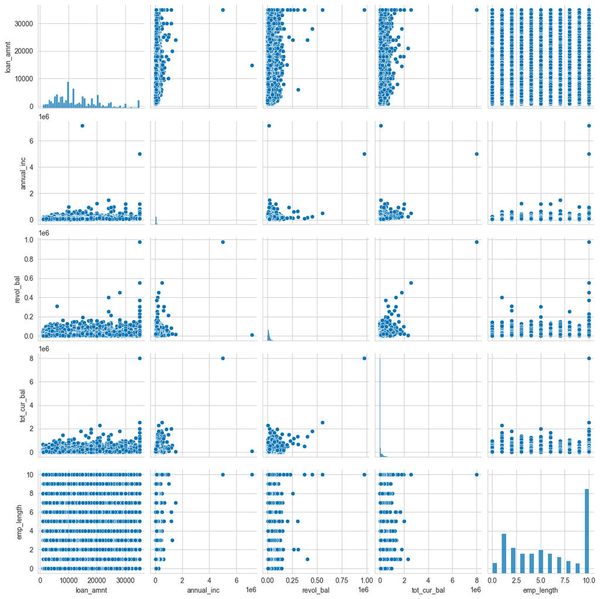

```python
#Code Block 04

df_outliers = df_loandata_clean[['loan_amnt','annual_inc', 'revol_bal', 'tot_cur_bal', 'emp_length']]
sns.pairplot(df_outliers)
```

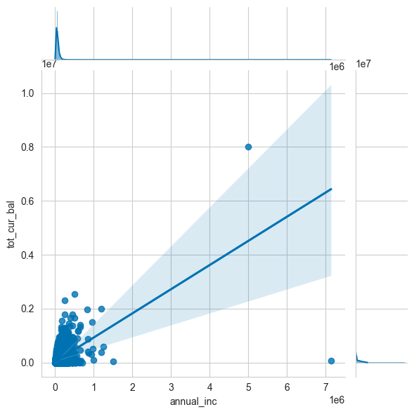

```python
#Code Block 05

sns.jointplot(x="annual_inc", y="tot_cur_bal", data=df_loandata_clean, kind='reg')
```

```python
#Code Block 06

df_loandata_clean['annual_inc'].value_counts()
```

```
annual_inc
60000.0    1456
50000.0    1395
40000.0    1165
45000.0    1137
65000.0    1110
           ...
79445.0       1
92200.0       1
70584.0       1
36717.0       1
39990.0       1
Name: count, Length: 4043, dtype: int64
```

```python
#Code Block 07

df_annual_inc = df_loandata_clean['annual_inc'].value_counts()
df_annual_inc = pd.DataFrame(df_annual_inc).reset_index()
print(df_annual_inc.columns)
#df_annual_inc.sort_values(by='index', ascending=False).head(5)
df_annual_inc.sort_values(by='annual_inc', ascending=False).head(5)
```

```
Index(['annual_inc', 'count'], dtype='object')
```

|  | annual_inc | count |
| --- | --- | --- |
| 1913 | 7141778.0 | 1 |
| 2031 | 5000000.0 | 1 |
| 3609 | 1500000.0 | 1 |
| 2413 | 1250000.0 | 1 |
| 698 | 1200000.0 | 2 |

**Note**: In the lecture, we used 'index' to sort values after calling reset_index(), as in:

df_annual_inc = df_loandata_clean['annual_inc'].value_counts() df_annual_inc = pd.DataFrame(df_annual_inc).reset_index() df_annual_inc.sort_values(by='index', ascending=False).head(5)

However, depending on the version of pandas or the structure of the resulting DataFrame, the default column name 'index' may not be preserved. For example, after reset_index(), the columns are named something like ['annual_inc', 'count'] instead, as you see above.

To avoid errors, always check the column names using df.columns, and sort using the actual column name (e.g., 'annual_inc') instead of 'index'.

#### Same output with one line of code

```python
#Code Block 08

pd.DataFrame(df_loandata_clean['annual_inc'].value_counts()).reset_index().sort_values(by='annual_inc', ascending=False).head(5)
```

|  | annual_inc | count |
| --- | --- | --- |
| 1913 | 7141778.0 | 1 |
| 2031 | 5000000.0 | 1 |
| 3609 | 1500000.0 | 1 |
| 2413 | 1250000.0 | 1 |
| 698 | 1200000.0 | 2 |

- Is it worth keeping these six data points?

```python
#Code Block 09

df_loandata_clean[df_loandata_clean['annual_inc'] >=1000000]
```

|  | member_id | loan_amnt | term | int_rate | annual_inc | delinq_2yrs | inq_last_6mths | mths_since_last_delinq | mths_since_last_record | open_acc | pub_rec | revol_bal | total_acc | total_debt_paid | princ_int_ratio | collections_12_mths_ex_med | mths_since_last_major_derog | acc_now_delinq | tot_coll_amt | tot_cur_bal | total_credit_rv | revol_util | sub_grade | emp_length | home_ownership | loan_status | reason |
| --- | --- | --- | --- | --- | --- | --- | --- | --- | --- | --- | --- | --- | --- | --- | --- | --- | --- | --- | --- | --- | --- | --- | --- | --- | --- | --- | --- |
| 9523 | 1797692 | 35000 | 36 | 12.12 | 1200000.0 | 0 | 2 | 71 | 0 | 5 | 0 | 20228 | 11 | 41374.598150 | 5.057241 | 0 | 0 | 0 | 0 | 2008009 | 42300 | 47.8 | B3 | 5 | MORTGAGE | Fully Paid | medical |
| 18299 | 1407521 | 24000 | 60 | 21.00 | 1500000.0 | 0 | 0 | 0 | 0 | 20 | 0 | 18544 | 32 | 9745.178479 | 0.964365 | 0 | 0 | 0 | 0 | 49281 | 24000 | 77.0 | E2 | 7 | OWN | Current | debt_consolidation |
| 30802 | 2432841 | 20000 | 36 | 8.90 | 1250000.0 | 0 | 2 | 0 | 0 | 19 | 0 | 22427 | 25 | 24948.034880 | 6.987437 | 0 | 0 | 0 | 0 | 575475 | 70700 | 31.7 | A5 | 3 | MORTGAGE | Fully Paid | other |
| 35284 | 2839463 | 35000 | 36 | 15.31 | 5000000.0 | 1 | 2 | 12 | 0 | 13 | 0 | 975800 | 36 | 42983.969100 | 4.313197 | 0 | 0 | 0 | 0 | 8000078 | 988000 | 0.0 | C2 | 10 | MORTGAGE | Fully Paid | credit_card |
| 36011 | 2926819 | 30000 | 36 | 11.14 | 1200000.0 | 0 | 0 | 0 | 0 | 16 | 0 | 81138 | 22 | 31219.956980 | 5.580399 | 0 | 0 | 0 | 0 | 375355 | 105400 | 78.2 | B2 | 6 | OWN | Fully Paid | debt_consolidation |
| 36944 | 3267055 | 14825 | 36 | 13.11 | 7141778.0 | 0 | 2 | 26 | 0 | 17 | 0 | 11351 | 31 | 16014.498790 | 6.165959 | 0 | 0 | 0 | 0 | 69548 | 16000 | 70.9 | B4 | 10 | MORTGAGE | Fully Paid | debt_consolidation |

```python
#Code Block 10

pd.DataFrame(df_loandata_clean['revol_bal'].value_counts()).reset_index().sort_values(by='revol_bal', ascending=False).head(10)
```

|  | revol_bal | count |
| --- | --- | --- |
| 13028 | 975800 | 1 |
| 12409 | 552758 | 1 |
| 11456 | 451481 | 1 |
| 11165 | 401258 | 1 |
| 12433 | 371817 | 1 |
| 12473 | 308071 | 1 |
| 12307 | 303993 | 1 |
| 12446 | 264260 | 1 |
| 11143 | 252191 | 1 |
| 12771 | 229112 | 1 |

- Is it worth keeping data points above 200,000?

```python
#Code Block 11

df_loandata_clean[df_loandata_clean['revol_bal'] >=200000]
```

|  | member_id | loan_amnt | term | int_rate | annual_inc | delinq_2yrs | inq_last_6mths | mths_since_last_delinq | mths_since_last_record | open_acc | pub_rec | revol_bal | total_acc | total_debt_paid | princ_int_ratio | collections_12_mths_ex_med | mths_since_last_major_derog | acc_now_delinq | tot_coll_amt | tot_cur_bal | total_credit_rv | revol_util | sub_grade | emp_length | home_ownership | loan_status | reason |
| --- | --- | --- | --- | --- | --- | --- | --- | --- | --- | --- | --- | --- | --- | --- | --- | --- | --- | --- | --- | --- | --- | --- | --- | --- | --- | --- | --- |
| 32964 | 2730966 | 25000 | 36 | 7.62 | 954285.00 | 0 | 0 | 0 | 0 | 16 | 0 | 212997 | 26 | 29878.690750 | 8.213175 | 0 | 0 | 0 | 0 | 1497087 | 260900 | 73.1 | A3 | 10 | MORTGAGE | Fully Paid | debt_consolidation |
| 33684 | 2739932 | 24000 | 36 | 6.62 | 160000.00 | 0 | 3 | 0 | 0 | 7 | 0 | 401258 | 19 | 26712.922830 | 9.557717 | 0 | 0 | 0 | 0 | 1328612 | 411000 | 73.6 | A2 | 1 | MORTGAGE | Fully Paid | credit_card |
| 33749 | 2740605 | 24000 | 60 | 17.27 | 141000.00 | 4 | 1 | 4 | 0 | 7 | 0 | 252191 | 26 | 28884.981830 | 2.717930 | 0 | 4 | 0 | 0 | 750932 | 251300 | 73.3 | C5 | 8 | MORTGAGE | Fully Paid | credit_card |
| 33906 | 2742178 | 28000 | 36 | 17.77 | 250000.00 | 0 | 5 | 0 | 0 | 9 | 0 | 451481 | 23 | 4657.071839 | 1.635285 | 0 | 0 | 0 | 0 | 1787296 | 544100 | 89.9 | D1 | 10 | MORTGAGE | Charged Off | other |
| 34510 | 2829819 | 35000 | 36 | 18.75 | 175000.00 | 0 | 2 | 0 | 0 | 6 | 0 | 229112 | 23 | 18254.606950 | 1.866418 | 0 | 0 | 0 | 0 | 936175 | 272000 | 41.0 | D3 | 10 | MORTGAGE | Charged Off | other |
| 35284 | 2839463 | 35000 | 36 | 15.31 | 5000000.00 | 1 | 2 | 12 | 0 | 13 | 0 | 975800 | 36 | 42983.969100 | 4.313197 | 0 | 0 | 0 | 0 | 8000078 | 988000 | 0.0 | C2 | 10 | MORTGAGE | Fully Paid | credit_card |
| 35982 | 2917830 | 35000 | 60 | 16.29 | 650000.00 | 0 | 1 | 0 | 0 | 12 | 0 | 303993 | 19 | 17484.410420 | 1.322268 | 0 | 0 | 0 | 0 | 1324144 | 334500 | 35.2 | C4 | 5 | MORTGAGE | Current | debt_consolidation |
| 36558 | 3017184 | 6000 | 36 | 16.29 | 200000.00 | 0 | 0 | 0 | 0 | 18 | 0 | 308071 | 29 | 7443.407485 | 4.223776 | 0 | 0 | 0 | 0 | 654874 | 312500 | 98.4 | C4 | 2 | MORTGAGE | Fully Paid | personal |
| 36940 | 3266877 | 35000 | 60 | 16.29 | 92974.96 | 0 | 0 | 0 | 0 | 8 | 0 | 371817 | 12 | 33597.189750 | 7.687290 | 0 | 0 | 0 | 0 | 487461 | 400400 | 98.3 | C4 | 10 | MORTGAGE | Fully Paid | debt_consolidation |
| 36982 | 3376772 | 35000 | 36 | 11.14 | 600000.00 | 0 | 1 | 27 | 0 | 12 | 0 | 264260 | 40 | 33933.807710 | 10.785791 | 0 | 0 | 0 | 0 | 1175696 | 344900 | 66.4 | B2 | 2 | MORTGAGE | Fully Paid | other |
| 37077 | 3417245 | 35000 | 60 | 16.29 | 500000.00 | 0 | 1 | 0 | 0 | 15 | 0 | 552758 | 42 | 34294.721920 | 37.003753 | 0 | 0 | 0 | 0 | 2547166 | 645800 | 53.4 | C4 | 10 | MORTGAGE | Fully Paid | debt_consolidation |

```python
#Code Block 12

pd.DataFrame(df_loandata_clean['tot_cur_bal'].value_counts()).reset_index().sort_values(by='tot_cur_bal', ascending=False).head(10)
```

|  | tot_cur_bal | count |
| --- | --- | --- |
| 7720 | 8000078 | 1 |
| 8941 | 2547166 | 1 |
| 19902 | 2302431 | 1 |
| 18070 | 2008009 | 1 |
| 18260 | 1967533 | 1 |
| 11751 | 1787296 | 1 |
| 12688 | 1785763 | 1 |
| 10901 | 1662481 | 1 |
| 7713 | 1657520 | 1 |
| 5236 | 1549458 | 1 |

```python
df_loandata_clean.head()
```

|  | member_id | loan_amnt | term | int_rate | annual_inc | delinq_2yrs | inq_last_6mths | mths_since_last_delinq | mths_since_last_record | open_acc | pub_rec | revol_bal | total_acc | total_debt_paid | princ_int_ratio | collections_12_mths_ex_med | mths_since_last_major_derog | acc_now_delinq | tot_coll_amt | tot_cur_bal | total_credit_rv | revol_util | sub_grade | emp_length | home_ownership | loan_status | reason |
| --- | --- | --- | --- | --- | --- | --- | --- | --- | --- | --- | --- | --- | --- | --- | --- | --- | --- | --- | --- | --- | --- | --- | --- | --- | --- | --- | --- |
| 0 | 1581986 | 9000 | 36 | 12.12 | 45000.0 | 0 | 3 | 0 | 0 | 11 | 0 | 7341 | 15 | 9595.467648 | 5.305665 | 0 | 0 | 0 | 0 | 0 | 0 | 41.9 | B3 | 6 | RENT | Fully Paid | debt_consolidation |
| 1 | 1751708 | 6625 | 36 | 11.14 | 28000.0 | 1 | 0 | 23 | 0 | 8 | 0 | 3493 | 14 | 4215.792902 | 4.538190 | 0 | 0 | 0 | 0 | 14017 | 7900 | 44.2 | B2 | 3 | RENT | Charged Off | personal |
| 2 | 1666916 | 9800 | 36 | 12.12 | 50000.0 | 0 | 0 | 0 | 0 | 10 | 0 | 19896 | 19 | 11324.488450 | 5.312891 | 0 | 0 | 0 | 0 | 0 | 0 | 72.2 | B3 | 10 | RENT | Fully Paid | credit_card |
| 3 | 1758003 | 4250 | 36 | 8.90 | 38000.0 | 2 | 3 | 21 | 0 | 9 | 0 | 97 | 14 | 4859.693597 | 10.904706 | 0 | 0 | 0 | 0 | 10956 | 3500 | 2.8 | A5 | 4 | OWN | Fully Paid | debt_consolidation |
| 4 | 1730191 | 16000 | 36 | 7.90 | 60000.0 | 0 | 0 | 28 | 0 | 16 | 0 | 22806 | 36 | 19124.243200 | 8.835044 | 0 | 0 | 0 | 0 | 254901 | 77100 | 29.6 | A4 | 10 | MORTGAGE | Fully Paid | personal |

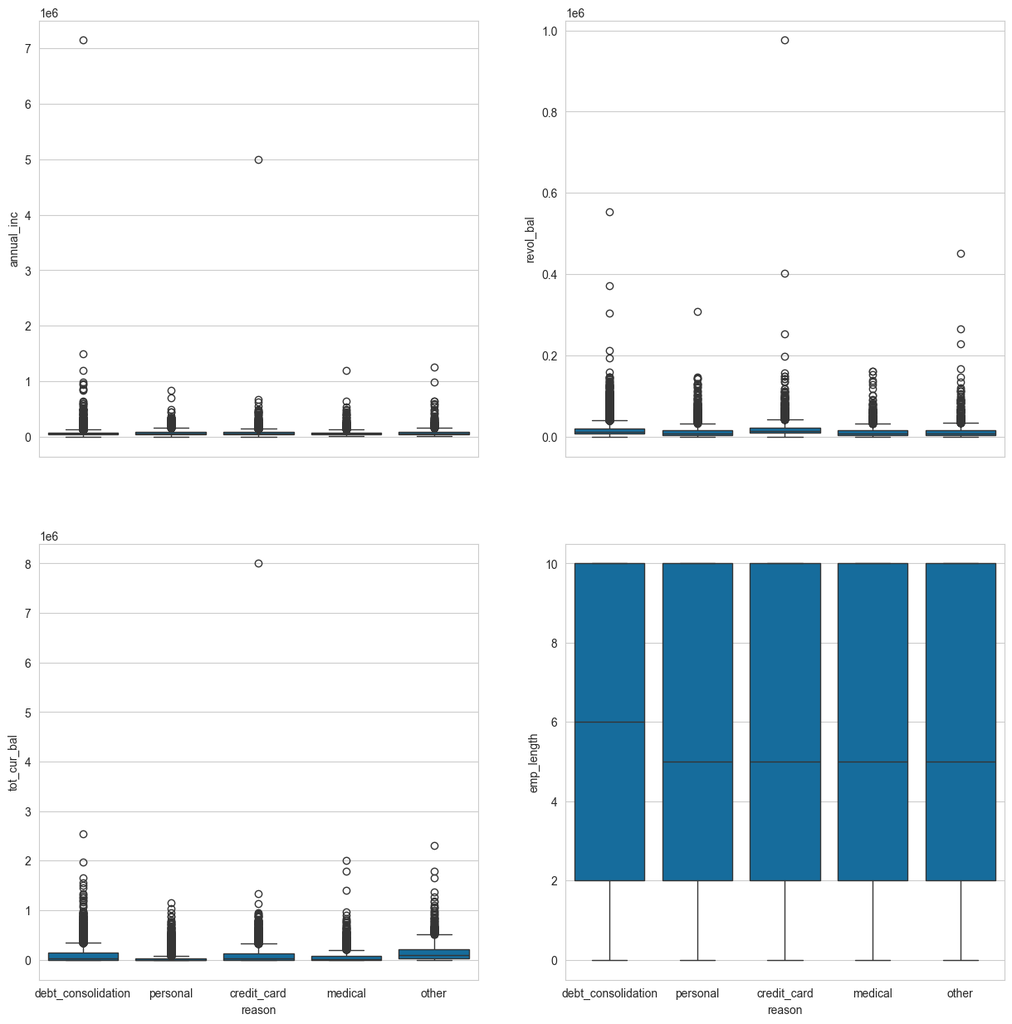

```python
#Code Block 13

f, axes = plt.subplots(2, 2, figsize=(15, 15), sharex=True)
sns.boxplot(y='annual_inc', x = 'reason',  data=df_loandata_clean, ax=axes[0,0])
sns.boxplot(y='revol_bal', x = 'reason',  data=df_loandata_clean, ax=axes[0,1])
sns.boxplot(y='tot_cur_bal', x = 'reason',  data=df_loandata_clean, ax=axes[1,0])
sns.boxplot(y='emp_length', x = 'reason',  data=df_loandata_clean, ax=axes[1,1])
```

Top

## Remove outliers

#### Why are we removing observations?

- Appleton gives mico loans to individuals that need help with debt consolidation, medical bills, etc. They are normal people that just need a short term loan. Therefore, the objective is not to predict outliers, but instead the average person that asks for a loan. Outliers may skew the results.

#### Therefore:

- Remove records with annual_inc > 1,000,000
- Remove records with revol_bal > 200,000
- Remove records with total current balance > 2,000,000
- For employee length we change that to categories and then dummy variables

```python
#Code Block 14

df_loandata_clean.shape
```

```
(37132, 27)
```

```python
#Code Block 15

df_loandata_clean.drop(df_loandata_clean[df_loandata_clean.annual_inc > 1000000].index, inplace=True)
df_loandata_clean.drop(df_loandata_clean[df_loandata_clean.revol_bal > 200000].index, inplace=True)

#df_loandata_clean.drop(df_loandata_clean[df_loandata_clean.tot_cur_bal > 2000000].index, inplace=True)
df_loandata_clean.shape
```

```
(37116, 27)
```

```python
#Code Block 16
df_loandata_clean = df_loandata_clean[df_loandata_clean['tot_cur_bal'] < 2000000]
df_loandata_clean.shape
```

```
(37115, 27)
```

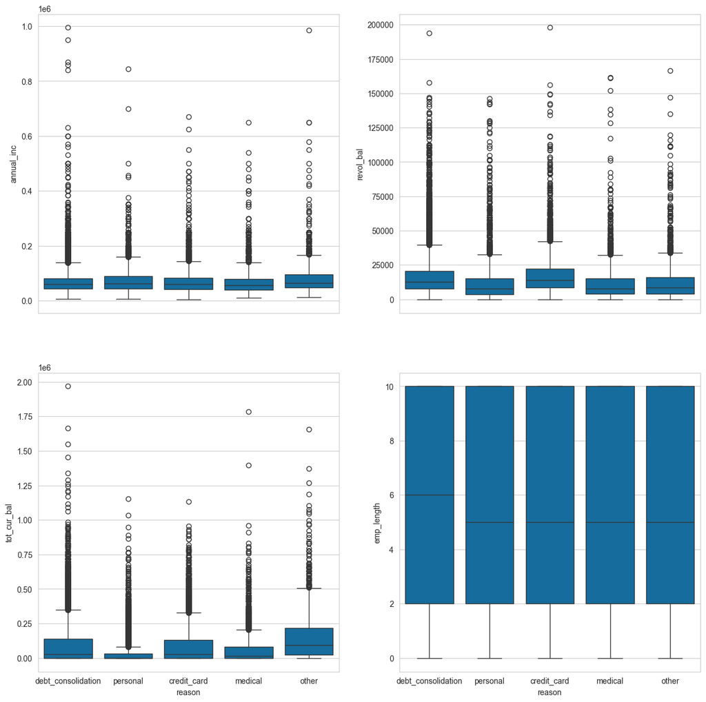

```python
#Code Block 17

f, axes = plt.subplots(2, 2, figsize=(15, 15), sharex=True)
sns.boxplot(y='annual_inc', x = 'reason',  data=df_loandata_clean, ax=axes[0,0])
sns.boxplot(y='revol_bal', x = 'reason',  data=df_loandata_clean, ax=axes[0,1])
sns.boxplot(y='tot_cur_bal', x = 'reason',  data=df_loandata_clean, ax=axes[1,0])
sns.boxplot(y='emp_length', x = 'reason',  data=df_loandata_clean, ax=axes[1,1])
```

## Re-code the Data

Top

## Recode categorical data - label encoder

### 4 ways to recode categorical data

- **label encoder** - changes categories to integers based on alphabetical order
- **hot one encoder** - changes one column of categorical data into several binary (dummy) columns
- **use a custom function** for changing categories to integers
- **merge** from a separate dataset

```python
#Code Block 18

df_loandata_clean.info()
```

```
<class 'pandas.core.frame.DataFrame'>
Index: 37115 entries, 0 to 37131
Data columns (total 27 columns):
 #   Column                       Non-Null Count  Dtype
---  ------                       --------------  -----
 0   member_id                    37115 non-null  int64
 1   loan_amnt                    37115 non-null  int64
 2   term                         37115 non-null  int64
 3   int_rate                     37115 non-null  float64
 4   annual_inc                   37115 non-null  float64
 5   delinq_2yrs                  37115 non-null  int64
 6   inq_last_6mths               37115 non-null  int64
 7   mths_since_last_delinq       37115 non-null  int64
 8   mths_since_last_record       37115 non-null  int64
 9   open_acc                     37115 non-null  int64
```

[output cut: 19 more lines]

### Convert all object features:

- sub_grade - label encoder
- loan_status - merge with new dataset
- reason - one-hot encoding
- home_ownership - one-hot encoding

### Convert non-linear features

- emp_length - will be converted to an object with a defined function and then encode with one-hot encoding

### Recode using Label Encoding

- Change subgrade to a numerical value and assume it is linear

```python
#Code Block 19

from sklearn.preprocessing import LabelEncoder
lc = LabelEncoder()
```

```python
#Code Block 20

df_loandata_clean.sub_grade.value_counts()
```

```
sub_grade
B3    3766
B4    2838
C1    2529
B5    2494
C2    2370
B2    2322
A4    1885
A5    1696
B1    1651
C4    1377
D1    1317
D2    1294
C3    1279
C5    1151
D3    1050
A3    1010
A1    1001
D4     991
A2     896
D5     803
E1     558
E2     522
E4     427
E3     418
E5     336
F1     286
F2     232
F3     175
F4     131
F5     124
G1      86
G2      51
G3      23
G4      17
G5       9
Name: count, dtype: int64
```

```python
#Code Block 21

df_loandata_clean.head()
```

|  | member_id | loan_amnt | term | int_rate | annual_inc | delinq_2yrs | inq_last_6mths | mths_since_last_delinq | mths_since_last_record | open_acc | pub_rec | revol_bal | total_acc | total_debt_paid | princ_int_ratio | collections_12_mths_ex_med | mths_since_last_major_derog | acc_now_delinq | tot_coll_amt | tot_cur_bal | total_credit_rv | revol_util | sub_grade | emp_length | home_ownership | loan_status | reason |
| --- | --- | --- | --- | --- | --- | --- | --- | --- | --- | --- | --- | --- | --- | --- | --- | --- | --- | --- | --- | --- | --- | --- | --- | --- | --- | --- | --- |
| 0 | 1581986 | 9000 | 36 | 12.12 | 45000.0 | 0 | 3 | 0 | 0 | 11 | 0 | 7341 | 15 | 9595.467648 | 5.305665 | 0 | 0 | 0 | 0 | 0 | 0 | 41.9 | B3 | 6 | RENT | Fully Paid | debt_consolidation |
| 1 | 1751708 | 6625 | 36 | 11.14 | 28000.0 | 1 | 0 | 23 | 0 | 8 | 0 | 3493 | 14 | 4215.792902 | 4.538190 | 0 | 0 | 0 | 0 | 14017 | 7900 | 44.2 | B2 | 3 | RENT | Charged Off | personal |
| 2 | 1666916 | 9800 | 36 | 12.12 | 50000.0 | 0 | 0 | 0 | 0 | 10 | 0 | 19896 | 19 | 11324.488450 | 5.312891 | 0 | 0 | 0 | 0 | 0 | 0 | 72.2 | B3 | 10 | RENT | Fully Paid | credit_card |
| 3 | 1758003 | 4250 | 36 | 8.90 | 38000.0 | 2 | 3 | 21 | 0 | 9 | 0 | 97 | 14 | 4859.693597 | 10.904706 | 0 | 0 | 0 | 0 | 10956 | 3500 | 2.8 | A5 | 4 | OWN | Fully Paid | debt_consolidation |
| 4 | 1730191 | 16000 | 36 | 7.90 | 60000.0 | 0 | 0 | 28 | 0 | 16 | 0 | 22806 | 36 | 19124.243200 | 8.835044 | 0 | 0 | 0 | 0 | 254901 | 77100 | 29.6 | A4 | 10 | MORTGAGE | Fully Paid | personal |

```python
#Code Block 22

df_loandata_clean['sub_grade'] = lc.fit_transform(df_loandata_clean['sub_grade'])
```

```python
#Code Block 23

df_loandata_clean['sub_grade'].value_counts()
```

```
sub_grade
7     3766
8     2838
10    2529
9     2494
11    2370
6     2322
3     1885
4     1696
5     1651
13    1377
15    1317
16    1294
12    1279
14    1151
```

[output cut: 22 more lines]

Top

## Recode Categorical using a Defined Function

```python
#Code Block 24

df_loandata_clean['emp_length'].value_counts()
```

```
emp_length
10    11104
1      5219
2      3359
5      3127
4      2632
3      2590
6      2573
7      2165
8      1635
0      1375
9      1336
Name: count, dtype: int64
```

### How to recode?

- 10 refers to 10 or more
- By talking to management, they believe that this can be changed to:
  - **10 or more**: 10
  - **7 to 9**: 7, 8, and 9
  - **4 to 6**: 4, 5, and 6
  - **3 or less**: 0, 1, 2, and 3

```python
#Code Block 25

def EmpLength(d):
    if d['emp_length'] == 10:
        return "10 or more"
    elif d['emp_length'] >= 7:
        return "7 to 9"
    elif d['emp_length'] >= 4:
        return "4 to 6"
    else:
        return "3 or less"
df_loandata_clean['emp_length_cat'] = df_loandata_clean.apply(EmpLength, axis = 1)
df_loandata_clean[['emp_length', 'emp_length_cat']].head()
```

|  | emp_length | emp_length_cat |
| --- | --- | --- |
| 0 | 6 | 4 to 6 |
| 1 | 3 | 3 or less |
| 2 | 10 | 10 or more |
| 3 | 4 | 4 to 6 |
| 4 | 10 | 10 or more |

```python
df_loandata_clean.head()
```

|  | member_id | loan_amnt | term | int_rate | annual_inc | delinq_2yrs | inq_last_6mths | mths_since_last_delinq | mths_since_last_record | open_acc | pub_rec | revol_bal | total_acc | total_debt_paid | princ_int_ratio | collections_12_mths_ex_med | mths_since_last_major_derog | acc_now_delinq | tot_coll_amt | tot_cur_bal | total_credit_rv | revol_util | sub_grade | emp_length | home_ownership | loan_status | reason | emp_length_cat |
| --- | --- | --- | --- | --- | --- | --- | --- | --- | --- | --- | --- | --- | --- | --- | --- | --- | --- | --- | --- | --- | --- | --- | --- | --- | --- | --- | --- | --- |
| 0 | 1581986 | 9000 | 36 | 12.12 | 45000.0 | 0 | 3 | 0 | 0 | 11 | 0 | 7341 | 15 | 9595.467648 | 5.305665 | 0 | 0 | 0 | 0 | 0 | 0 | 41.9 | 7 | 6 | RENT | Fully Paid | debt_consolidation | 4 to 6 |
| 1 | 1751708 | 6625 | 36 | 11.14 | 28000.0 | 1 | 0 | 23 | 0 | 8 | 0 | 3493 | 14 | 4215.792902 | 4.538190 | 0 | 0 | 0 | 0 | 14017 | 7900 | 44.2 | 6 | 3 | RENT | Charged Off | personal | 3 or less |
| 2 | 1666916 | 9800 | 36 | 12.12 | 50000.0 | 0 | 0 | 0 | 0 | 10 | 0 | 19896 | 19 | 11324.488450 | 5.312891 | 0 | 0 | 0 | 0 | 0 | 0 | 72.2 | 7 | 10 | RENT | Fully Paid | credit_card | 10 or more |
| 3 | 1758003 | 4250 | 36 | 8.90 | 38000.0 | 2 | 3 | 21 | 0 | 9 | 0 | 97 | 14 | 4859.693597 | 10.904706 | 0 | 0 | 0 | 0 | 10956 | 3500 | 2.8 | 4 | 4 | OWN | Fully Paid | debt_consolidation | 4 to 6 |
| 4 | 1730191 | 16000 | 36 | 7.90 | 60000.0 | 0 | 0 | 28 | 0 | 16 | 0 | 22806 | 36 | 19124.243200 | 8.835044 | 0 | 0 | 0 | 0 | 254901 | 77100 | 29.6 | 3 | 10 | MORTGAGE | Fully Paid | personal | 10 or more |

Top

## Recode Categorical using dummy variables

### How to automate the dropping of the largest dummy variable

```python
#Code Block 26

df_loandata_clean['home_ownership'].value_counts()
```

```
home_ownership
MORTGAGE    18081
RENT        16096
OWN          2938
Name: count, dtype: int64
```

```python
#Code Block 27

df_dummy = pd.DataFrame(df_loandata_clean['home_ownership'].value_counts().reset_index())
df_dummy
```

|  | home_ownership | count |
| --- | --- | --- |
| 0 | MORTGAGE | 18081 |
| 1 | RENT | 16096 |
| 2 | OWN | 2938 |

```python
#Code Block 28

var_dummy = df_dummy.iloc[0, 0]
var_dummy
```

```
'MORTGAGE'
```

```python
#Code Block 29

var_dummy_prefix = "home"
var_dumpre = var_dummy_prefix + "_" +  var_dummy
var_dumpre
```

```
'home_MORTGAGE'
```

```python
#Code Block 29

#Added  dtype=float to convert to display 0/1 values than the boolean
dummies = pd.get_dummies(df_loandata_clean['home_ownership'], drop_first = False, prefix=var_dummy_prefix, dtype=float)
dummies.head()
```

|  | home_MORTGAGE | home_OWN | home_RENT |
| --- | --- | --- | --- |
| 0 | 0.0 | 0.0 | 1.0 |
| 1 | 0.0 | 0.0 | 1.0 |
| 2 | 0.0 | 0.0 | 1.0 |
| 3 | 0.0 | 1.0 | 0.0 |
| 4 | 1.0 | 0.0 | 0.0 |

```python
#Code Block 30

dummies = dummies.drop(var_dumpre, axis = 1)
dummies.head()
```

|  | home_OWN | home_RENT |
| --- | --- | --- |
| 0 | 0.0 | 1.0 |
| 1 | 0.0 | 1.0 |
| 2 | 0.0 | 1.0 |
| 3 | 1.0 | 0.0 |
| 4 | 0.0 | 0.0 |

```python
#Code Block 32

df_loandata_clean = pd.concat([df_loandata_clean, dummies], axis = 1)
df_loandata_clean.info()
```

```
<class 'pandas.core.frame.DataFrame'>
Index: 37115 entries, 0 to 37131
Data columns (total 30 columns):
 #   Column                       Non-Null Count  Dtype
---  ------                       --------------  -----
 0   member_id                    37115 non-null  int64
 1   loan_amnt                    37115 non-null  int64
 2   term                         37115 non-null  int64
 3   int_rate                     37115 non-null  float64
 4   annual_inc                   37115 non-null  float64
 5   delinq_2yrs                  37115 non-null  int64
 6   inq_last_6mths               37115 non-null  int64
 7   mths_since_last_delinq       37115 non-null  int64
 8   mths_since_last_record       37115 non-null  int64
 9   open_acc                     37115 non-null  int64
```

[output cut: 22 more lines]

### Create dummy variables in one code block

```python
#Code Block 33

#Create prefix for dummy variables
var_dummy_prefix = "reason"


#Find the highest count category
df_dummy = pd.DataFrame(df_loandata_clean['reason'].value_counts().reset_index())
var_dummy = df_dummy.iloc[0, 0]

#Create variable to drop the highest count column
var_dumpre = var_dummy_prefix + "_" +  var_dummy

#Create dummy variables
dummies = pd.get_dummies(df_loandata_clean['reason'], drop_first = False, prefix=var_dummy_prefix, dtype=float)

#Drop the highest count dummy variable
dummies = dummies.drop(var_dumpre, axis = 1)

#Concat the dummy variables to the main dataset
df_loandata_clean = pd.concat([df_loandata_clean, dummies], axis = 1)

#Display the variables and new dataset

display(df_dummy)
print("----------------------")
print("Highest Count:")
print(var_dummy)
print("----------------------")

display(dummies.head())
df_loandata_clean.head()
```

|  | reason | count |
| --- | --- | --- |
| 0 | debt_consolidation | 22312 |
| 1 | credit_card | 7234 |
| 2 | personal | 3121 |
| 3 | other | 2270 |
| 4 | medical | 2178 |

```
----------------------
Highest Count:
debt_consolidation
----------------------
```

|  | reason_credit_card | reason_medical | reason_other | reason_personal |
| --- | --- | --- | --- | --- |
| 0 | 0.0 | 0.0 | 0.0 | 0.0 |
| 1 | 0.0 | 0.0 | 0.0 | 1.0 |
| 2 | 1.0 | 0.0 | 0.0 | 0.0 |
| 3 | 0.0 | 0.0 | 0.0 | 0.0 |
| 4 | 0.0 | 0.0 | 0.0 | 1.0 |

|  | member_id | loan_amnt | term | int_rate | annual_inc | delinq_2yrs | inq_last_6mths | mths_since_last_delinq | mths_since_last_record | open_acc | pub_rec | revol_bal | total_acc | total_debt_paid | princ_int_ratio | collections_12_mths_ex_med | mths_since_last_major_derog | acc_now_delinq | tot_coll_amt | tot_cur_bal | total_credit_rv | revol_util | sub_grade | emp_length | home_ownership | loan_status | reason | emp_length_cat | home_OWN | … |
| --- | --- | --- | --- | --- | --- | --- | --- | --- | --- | --- | --- | --- | --- | --- | --- | --- | --- | --- | --- | --- | --- | --- | --- | --- | --- | --- | --- | --- | --- | --- |
| 0 | 1581986 | 9000 | 36 | 12.12 | 45000.0 | 0 | 3 | 0 | 0 | 11 | 0 | 7341 | 15 | 9595.467648 | 5.305665 | 0 | 0 | 0 | 0 | 0 | 0 | 41.9 | 7 | 6 | RENT | Fully Paid | debt_consolidation | 4 to 6 | 0.0 | … |
| 1 | 1751708 | 6625 | 36 | 11.14 | 28000.0 | 1 | 0 | 23 | 0 | 8 | 0 | 3493 | 14 | 4215.792902 | 4.538190 | 0 | 0 | 0 | 0 | 14017 | 7900 | 44.2 | 6 | 3 | RENT | Charged Off | personal | 3 or less | 0.0 | … |
| 2 | 1666916 | 9800 | 36 | 12.12 | 50000.0 | 0 | 0 | 0 | 0 | 10 | 0 | 19896 | 19 | 11324.488450 | 5.312891 | 0 | 0 | 0 | 0 | 0 | 0 | 72.2 | 7 | 10 | RENT | Fully Paid | credit_card | 10 or more | 0.0 | … |
| 3 | 1758003 | 4250 | 36 | 8.90 | 38000.0 | 2 | 3 | 21 | 0 | 9 | 0 | 97 | 14 | 4859.693597 | 10.904706 | 0 | 0 | 0 | 0 | 10956 | 3500 | 2.8 | 4 | 4 | OWN | Fully Paid | debt_consolidation | 4 to 6 | 1.0 | … |
| 4 | 1730191 | 16000 | 36 | 7.90 | 60000.0 | 0 | 0 | 28 | 0 | 16 | 0 | 22806 | 36 | 19124.243200 | 8.835044 | 0 | 0 | 0 | 0 | 254901 | 77100 | 29.6 | 3 | 10 | MORTGAGE | Fully Paid | personal | 10 or more | 0.0 | … |

```python
#Code Block 34

#Create prefix for dummy variables
var_dummy_prefix = "emp"


#Find the highest count category
df_dummy = pd.DataFrame(df_loandata_clean['emp_length_cat'].value_counts().reset_index())
var_dummy = df_dummy.iloc[0, 0]

#Create variable to drop the highest count column
var_dumpre = var_dummy_prefix + "_" +  var_dummy

#Create dummy variables
dummies = pd.get_dummies(df_loandata_clean['emp_length_cat'], drop_first = False, prefix=var_dummy_prefix, dtype=float)

#Drop the highest count dummy variable
dummies = dummies.drop(var_dumpre, axis = 1)

#Concat the dummy variables to the main dataset
df_loandata_clean = pd.concat([df_loandata_clean, dummies], axis = 1)

#Display the variables and new dataset

display(df_dummy)
print("----------------------")
print("Highest Count:")
print(var_dummy)
print("----------------------")

display(dummies.head())
df_loandata_clean.head()
```

|  | emp_length_cat | count |
| --- | --- | --- |
| 0 | 3 or less | 12543 |
| 1 | 10 or more | 11104 |
| 2 | 4 to 6 | 8332 |
| 3 | 7 to 9 | 5136 |

```
----------------------
Highest Count:
3 or less
----------------------
```

|  | emp_10 or more | emp_4 to 6 | emp_7 to 9 |
| --- | --- | --- | --- |
| 0 | 0.0 | 1.0 | 0.0 |
| 1 | 0.0 | 0.0 | 0.0 |
| 2 | 1.0 | 0.0 | 0.0 |
| 3 | 0.0 | 1.0 | 0.0 |
| 4 | 1.0 | 0.0 | 0.0 |

|  | member_id | loan_amnt | term | int_rate | annual_inc | delinq_2yrs | inq_last_6mths | mths_since_last_delinq | mths_since_last_record | open_acc | pub_rec | revol_bal | total_acc | total_debt_paid | princ_int_ratio | collections_12_mths_ex_med | mths_since_last_major_derog | acc_now_delinq | tot_coll_amt | tot_cur_bal | total_credit_rv | revol_util | sub_grade | emp_length | home_ownership | loan_status | reason | emp_length_cat | home_OWN | … |
| --- | --- | --- | --- | --- | --- | --- | --- | --- | --- | --- | --- | --- | --- | --- | --- | --- | --- | --- | --- | --- | --- | --- | --- | --- | --- | --- | --- | --- | --- | --- |
| 0 | 1581986 | 9000 | 36 | 12.12 | 45000.0 | 0 | 3 | 0 | 0 | 11 | 0 | 7341 | 15 | 9595.467648 | 5.305665 | 0 | 0 | 0 | 0 | 0 | 0 | 41.9 | 7 | 6 | RENT | Fully Paid | debt_consolidation | 4 to 6 | 0.0 | … |
| 1 | 1751708 | 6625 | 36 | 11.14 | 28000.0 | 1 | 0 | 23 | 0 | 8 | 0 | 3493 | 14 | 4215.792902 | 4.538190 | 0 | 0 | 0 | 0 | 14017 | 7900 | 44.2 | 6 | 3 | RENT | Charged Off | personal | 3 or less | 0.0 | … |
| 2 | 1666916 | 9800 | 36 | 12.12 | 50000.0 | 0 | 0 | 0 | 0 | 10 | 0 | 19896 | 19 | 11324.488450 | 5.312891 | 0 | 0 | 0 | 0 | 0 | 0 | 72.2 | 7 | 10 | RENT | Fully Paid | credit_card | 10 or more | 0.0 | … |
| 3 | 1758003 | 4250 | 36 | 8.90 | 38000.0 | 2 | 3 | 21 | 0 | 9 | 0 | 97 | 14 | 4859.693597 | 10.904706 | 0 | 0 | 0 | 0 | 10956 | 3500 | 2.8 | 4 | 4 | OWN | Fully Paid | debt_consolidation | 4 to 6 | 1.0 | … |
| 4 | 1730191 | 16000 | 36 | 7.90 | 60000.0 | 0 | 0 | 28 | 0 | 16 | 0 | 22806 | 36 | 19124.243200 | 8.835044 | 0 | 0 | 0 | 0 | 254901 | 77100 | 29.6 | 3 | 10 | MORTGAGE | Fully Paid | personal | 10 or more | 0.0 | … |

### What to do with Term?

- Term is the number of months for each loan (36 or 60 months)
- Since it is not a linear relationship, it is actually a label (based on numbers), it should be treated as a label/categorical variable.

```python
#Code Block 35

df_loandata_clean['term'].value_counts()
```

```
term
36    30325
60     6790
Name: count, dtype: int64
```

### How to code?

- Since most loans are for 36 months, we will want to see if 60 month term loans have an effect on the loan amount.

```python
#Code Block 36

#Create prefix for dummy variables
var_dummy_prefix = "term"


#Find the highest count category
df_dummy = pd.DataFrame(df_loandata_clean['term'].value_counts().reset_index())
var_dummy = df_dummy.iloc[0, 0]

#Create variable to drop the highest count column

#NOTE: Since 60 is an integer, you need to set it as a string before you can concatenate
var_dumpre = var_dummy_prefix + "_" +  str(var_dummy)

#Create dummy variables
dummies = pd.get_dummies(df_loandata_clean['term'], drop_first = False, prefix=var_dummy_prefix, dtype=float)

#Drop the highest count dummy variable
dummies = dummies.drop(var_dumpre, axis = 1)

#Concat the dummy variables to the main dataset
df_loandata_clean = pd.concat([df_loandata_clean, dummies], axis = 1)

#Display the variables and new dataset

display(df_dummy)
print("----------------------")
print("Highest Count:")
print(var_dummy)
print("----------------------")

display(dummies.head())
df_loandata_clean.head()
```

|  | term | count |
| --- | --- | --- |
| 0 | 36 | 30325 |
| 1 | 60 | 6790 |

```
----------------------
Highest Count:
36
----------------------
```

|  | term_60 |
| --- | --- |
| 0 | 0.0 |
| 1 | 0.0 |
| 2 | 0.0 |
| 3 | 0.0 |
| 4 | 0.0 |

|  | member_id | loan_amnt | term | int_rate | annual_inc | delinq_2yrs | inq_last_6mths | mths_since_last_delinq | mths_since_last_record | open_acc | pub_rec | revol_bal | total_acc | total_debt_paid | princ_int_ratio | collections_12_mths_ex_med | mths_since_last_major_derog | acc_now_delinq | tot_coll_amt | tot_cur_bal | total_credit_rv | revol_util | sub_grade | emp_length | home_ownership | loan_status | reason | emp_length_cat | home_OWN | … |
| --- | --- | --- | --- | --- | --- | --- | --- | --- | --- | --- | --- | --- | --- | --- | --- | --- | --- | --- | --- | --- | --- | --- | --- | --- | --- | --- | --- | --- | --- | --- |
| 0 | 1581986 | 9000 | 36 | 12.12 | 45000.0 | 0 | 3 | 0 | 0 | 11 | 0 | 7341 | 15 | 9595.467648 | 5.305665 | 0 | 0 | 0 | 0 | 0 | 0 | 41.9 | 7 | 6 | RENT | Fully Paid | debt_consolidation | 4 to 6 | 0.0 | … |
| 1 | 1751708 | 6625 | 36 | 11.14 | 28000.0 | 1 | 0 | 23 | 0 | 8 | 0 | 3493 | 14 | 4215.792902 | 4.538190 | 0 | 0 | 0 | 0 | 14017 | 7900 | 44.2 | 6 | 3 | RENT | Charged Off | personal | 3 or less | 0.0 | … |
| 2 | 1666916 | 9800 | 36 | 12.12 | 50000.0 | 0 | 0 | 0 | 0 | 10 | 0 | 19896 | 19 | 11324.488450 | 5.312891 | 0 | 0 | 0 | 0 | 0 | 0 | 72.2 | 7 | 10 | RENT | Fully Paid | credit_card | 10 or more | 0.0 | … |
| 3 | 1758003 | 4250 | 36 | 8.90 | 38000.0 | 2 | 3 | 21 | 0 | 9 | 0 | 97 | 14 | 4859.693597 | 10.904706 | 0 | 0 | 0 | 0 | 10956 | 3500 | 2.8 | 4 | 4 | OWN | Fully Paid | debt_consolidation | 4 to 6 | 1.0 | … |
| 4 | 1730191 | 16000 | 36 | 7.90 | 60000.0 | 0 | 0 | 28 | 0 | 16 | 0 | 22806 | 36 | 19124.243200 | 8.835044 | 0 | 0 | 0 | 0 | 254901 | 77100 | 29.6 | 3 | 10 | MORTGAGE | Fully Paid | personal | 10 or more | 0.0 | … |

Top

## Recode Categorical using by merging two datasets

```python
#Code Block 37
#url = 'https://data63206330.file.core.windows.net/data6320/Loan_is_Bad.csv?sp=rl&st=2021-02-13T18:33:54Z&se=2023-11-14T18:33:00Z&sv=2019-12-12&sig=R676QM0gw%2BH8aat0HwXz81yB8EmxN5R93cK9aXSUziw%3D&sr=f'
df_loanisbad = pd.read_csv("data/Loan_is_Bad.csv", index_col = None, header = 0)
df_loanisbad
```

|  | loan_status | loan_is_bad |
| --- | --- | --- |
| 0 | Charged Off | 1 |
| 1 | Current | 0 |
| 2 | Fully Paid | 0 |
| 3 | In Grace Period | 0 |
| 4 | Late (16-30 days) | 0 |
| 5 | Late (31-120 days) | 1 |
| 6 | Default | 1 |

```python
#Code Block 38

df_loandata_clean['loan_status'].value_counts()
```

```
loan_status
Fully Paid            28510
Charged Off            5502
Current                2775
Late (31-120 days)      213
In Grace Period          87
Late (16-30 days)        22
Default                   6
Name: count, dtype: int64
```

```python
#Code Block 39

df_loandata_clean = pd.merge(df_loandata_clean, df_loanisbad, on='loan_status', how='left')
```

```python
#Code Block 40

df_loandata_clean.info()
```

```
<class 'pandas.core.frame.DataFrame'>
RangeIndex: 37115 entries, 0 to 37114
Data columns (total 44 columns):
 #   Column                       Non-Null Count  Dtype
---  ------                       --------------  -----
 0   member_id                    37115 non-null  int64
 1   loan_amnt                    37115 non-null  int64
 2   term                         37115 non-null  int64
 3   int_rate                     37115 non-null  float64
 4   annual_inc                   37115 non-null  float64
 5   delinq_2yrs                  37115 non-null  int64
 6   inq_last_6mths               37115 non-null  int64
 7   mths_since_last_delinq       37115 non-null  int64
 8   mths_since_last_record       37115 non-null  int64
 9   open_acc                     37115 non-null  int64
```

[output cut: 36 more lines]

```python
df_loandata_clean.head()
```

|  | member_id | loan_amnt | term | int_rate | annual_inc | delinq_2yrs | inq_last_6mths | mths_since_last_delinq | mths_since_last_record | open_acc | pub_rec | revol_bal | total_acc | total_debt_paid | princ_int_ratio | collections_12_mths_ex_med | mths_since_last_major_derog | acc_now_delinq | tot_coll_amt | tot_cur_bal | total_credit_rv | revol_util | sub_grade | emp_length | home_ownership | loan_status | reason | emp_length_cat | home_OWN | … |
| --- | --- | --- | --- | --- | --- | --- | --- | --- | --- | --- | --- | --- | --- | --- | --- | --- | --- | --- | --- | --- | --- | --- | --- | --- | --- | --- | --- | --- | --- | --- |
| 0 | 1581986 | 9000 | 36 | 12.12 | 45000.0 | 0 | 3 | 0 | 0 | 11 | 0 | 7341 | 15 | 9595.467648 | 5.305665 | 0 | 0 | 0 | 0 | 0 | 0 | 41.9 | 7 | 6 | RENT | Fully Paid | debt_consolidation | 4 to 6 | 0.0 | … |
| 1 | 1751708 | 6625 | 36 | 11.14 | 28000.0 | 1 | 0 | 23 | 0 | 8 | 0 | 3493 | 14 | 4215.792902 | 4.538190 | 0 | 0 | 0 | 0 | 14017 | 7900 | 44.2 | 6 | 3 | RENT | Charged Off | personal | 3 or less | 0.0 | … |
| 2 | 1666916 | 9800 | 36 | 12.12 | 50000.0 | 0 | 0 | 0 | 0 | 10 | 0 | 19896 | 19 | 11324.488450 | 5.312891 | 0 | 0 | 0 | 0 | 0 | 0 | 72.2 | 7 | 10 | RENT | Fully Paid | credit_card | 10 or more | 0.0 | … |
| 3 | 1758003 | 4250 | 36 | 8.90 | 38000.0 | 2 | 3 | 21 | 0 | 9 | 0 | 97 | 14 | 4859.693597 | 10.904706 | 0 | 0 | 0 | 0 | 10956 | 3500 | 2.8 | 4 | 4 | OWN | Fully Paid | debt_consolidation | 4 to 6 | 1.0 | … |
| 4 | 1730191 | 16000 | 36 | 7.90 | 60000.0 | 0 | 0 | 28 | 0 | 16 | 0 | 22806 | 36 | 19124.243200 | 8.835044 | 0 | 0 | 0 | 0 | 254901 | 77100 | 29.6 | 3 | 10 | MORTGAGE | Fully Paid | personal | 10 or more | 0.0 | … |

## The Final Dataset

```python
#Code Block 41

df_loandata_clean = df_loandata_clean.drop(['term','emp_length','home_ownership', 'loan_status', 'reason', 'emp_length_cat'], axis=1)
df_loandata_clean.info()
```

```
<class 'pandas.core.frame.DataFrame'>
RangeIndex: 37115 entries, 0 to 37114
Data columns (total 38 columns):
 #   Column                       Non-Null Count  Dtype
---  ------                       --------------  -----
 0   member_id                    37115 non-null  int64
 1   loan_amnt                    37115 non-null  int64
 2   int_rate                     37115 non-null  float64
 3   annual_inc                   37115 non-null  float64
 4   delinq_2yrs                  37115 non-null  int64
 5   inq_last_6mths               37115 non-null  int64
 6   mths_since_last_delinq       37115 non-null  int64
 7   mths_since_last_record       37115 non-null  int64
 8   open_acc                     37115 non-null  int64
 9   pub_rec                      37115 non-null  int64
```

[output cut: 30 more lines]

```python
#Code Block 42

#df_loandata_clean.to_csv('data/Appleton_CleanData.csv')
```